# assignment 4 car insurance

Jack Wright

11/2/2021

```r
library(tidyverse)
library(GGally)
library(here)
```

## Load Data

```r
file<-here('data','insurance_training_data.csv')
df_raw<-read_csv(file)
```

## Data Exploration

```r
summary(df_raw)
```

```
##      INDEX        TARGET_FLAG       TARGET_AMT        KIDSDRIV
##  Min.   :    1   Min.   :0.0000   Min.   :     0   Min.   :0.0000
##  1st Qu.: 2559   1st Qu.:0.0000   1st Qu.:     0   1st Qu.:0.0000
##  Median : 5133   Median :0.0000   Median :     0   Median :0.0000
##  Mean   : 5152   Mean   :0.2638   Mean   :  1504   Mean   :0.1711
##  3rd Qu.: 7745   3rd Qu.:1.0000   3rd Qu.:  1036   3rd Qu.:0.0000
##  Max.   :10302   Max.   :1.0000   Max.   :107586   Max.   :4.0000
##
##       AGE           HOMEKIDS           YOJ          INCOME
##  Min.   :16.00   Min.   :0.0000   Min.   : 0.0   Length:8161
##  1st Qu.:39.00   1st Qu.:0.0000   1st Qu.: 9.0   Class :character
##  Median :45.00   Median :0.0000   Median :11.0   Mode  :character
##  Mean   :44.79   Mean   :0.7212   Mean   :10.5
##  3rd Qu.:51.00   3rd Qu.:1.0000   3rd Qu.:13.0
##  Max.   :81.00   Max.   :5.0000   Max.   :23.0
##  NA's   :6                        NA's   :454
##    PARENT1            HOME_VAL           MSTATUS              SEX
##  Length:8161        Length:8161        Length:8161        Length:8161
##  Class :character   Class :character   Class :character   Class :character
##  Mode  :character   Mode  :character   Mode  :character   Mode  :character
##
##
##
##
##   EDUCATION             JOB               TRAVTIME        CAR_USE
##  Length:8161        Length:8161        Min.   :  5.00   Length:8161
##  Class :character   Class :character   1st Qu.: 22.00   Class :character
##  Mode  :character   Mode  :character   Median : 33.00   Mode  :character
##                                        Mean   : 33.49
##                                        3rd Qu.: 44.00
##                                        Max.   :142.00
##
##    BLUEBOOK              TIF           CAR_TYPE           RED_CAR
##  Length:8161        Min.   : 1.000   Length:8161        Length:8161
##  Class :character   1st Qu.: 1.000   Class :character   Class :character
##  Mode  :character   Median : 4.000   Mode  :character   Mode  :character
##                     Mean   : 5.351
##                     3rd Qu.: 7.000
##                     Max.   :25.000
##
##    OLDCLAIM            CLM_FREQ        REVOKED             MVR_PTS
##  Length:8161        Min.   :0.0000   Length:8161        Min.   : 0.000
##  Class :character   1st Qu.:0.0000   Class :character   1st Qu.: 0.000
##  Mode  :character   Median :0.0000   Mode  :character   Median : 1.000
##                     Mean   :0.7986                      Mean   : 1.696
##                     3rd Qu.:2.0000                      3rd Qu.: 3.000
##                     Max.   :5.0000                      Max.   :13.000
##
##     CAR_AGE        URBANICITY
##  Min.   :-3.000   Length:8161
##  1st Qu.: 1.000   Class :character
##  Median : 8.000   Mode  :character
##  Mean   : 8.328
##  3rd Qu.:12.000
##  Max.   :28.000
##  NA's   :510
```

### Fixing columns with dollar values to numeric

```r
#get rid of all dollar signs and commas in the prices

df<-mutate_if(as_tibble(df_raw),
          is.character,
          str_replace_all, pattern='\\$|,',replacement='')


#convertito numeric if the column seems numeric
is_all_numeric <- function(x) {
  !any(is.na(suppressWarnings(as.numeric(na.omit(x))))) & is.character(x)
}
df<-df %>%
  mutate_if(is_all_numeric,as.numeric)
```

### converting factor columns

```r
#converting to factor

factor_list<-list('TARGET_FLAG',"MSTATUS",'SEX','EDUCATION','JOB','CAR_USE','URBANICITY','CAR_TYPE','PARENT1','RED_CAR','REVOKED')
df<-df %>%
       mutate_each_(funs(factor(.)),factor_list)
str(df)
```

```
## tibble [8,161 x 26] (S3: tbl_df/tbl/data.frame)
##  $ INDEX      : num [1:8161] 1 2 4 5 6 7 8 11 12 13 ...
##  $ TARGET_FLAG: Factor w/ 2 levels "0","1": 1 1 1 1 1 2 1 2 2 1 ...
##  $ TARGET_AMT : num [1:8161] 0 0 0 0 0 ...
##  $ KIDSDRIV   : num [1:8161] 0 0 0 0 0 0 0 1 0 0 ...
##  $ AGE        : num [1:8161] 60 43 35 51 50 34 54 37 34 50 ...
##  $ HOMEKIDS   : num [1:8161] 0 0 1 0 0 1 0 2 0 0 ...
##  $ YOJ        : num [1:8161] 11 11 10 14 NA 12 NA NA 10 7 ...
##  $ INCOME     : num [1:8161] 67349 91449 16039 NA 114986 ...
##  $ PARENT1    : Factor w/ 2 levels "No","Yes": 1 1 1 1 1 2 1 1 1 1 ...
##  $ HOME_VAL   : num [1:8161] 0 257252 124191 306251 243925 ...
##  $ MSTATUS    : Factor w/ 2 levels "Yes","z_No": 2 2 1 1 1 2 1 1 2 2 ...
##  $ SEX        : Factor w/ 2 levels "M","z_F": 1 1 2 1 2 2 2 1 2 1 ...
##  $ EDUCATION  : Factor w/ 5 levels "<High School",..: 4 5 5 1 4 2 1 2 2 2 ...
##  $ JOB        : Factor w/ 8 levels "Clerical","Doctor",..: 6 8 1 8 2 8 8 8 1 6 ...
##  $ TRAVTIME   : num [1:8161] 14 22 5 32 36 46 33 44 34 48 ...
##  $ CAR_USE    : Factor w/ 2 levels "Commercial","Private": 2 1 2 2 2 1 2 1 2 1 ...
##  $ BLUEBOOK   : num [1:8161] 14230 14940 4010 15440 18000 ...
##  $ TIF        : num [1:8161] 11 1 4 7 1 1 1 1 1 7 ...
##  $ CAR_TYPE   : Factor w/ 6 levels "Minivan","Panel Truck",..: 1 1 6 1 6 4 6 5 6 5 ...
##  $ RED_CAR    : Factor w/ 2 levels "no","yes": 2 2 1 2 1 1 1 2 1 1 ...
##  $ OLDCLAIM   : num [1:8161] 4461 0 38690 0 19217 ...
##  $ CLM_FREQ   : num [1:8161] 2 0 2 0 2 0 0 1 0 0 ...
##  $ REVOKED    : Factor w/ 2 levels "No","Yes": 1 1 1 1 2 1 1 2 1 1 ...
##  $ MVR_PTS    : num [1:8161] 3 0 3 0 3 0 0 10 0 1 ...
##  $ CAR_AGE    : num [1:8161] 18 1 10 6 17 7 1 7 1 17 ...
##  $ URBANICITY : Factor w/ 2 levels "Highly Urban/ Urban",..: 1 1 1 1 1 1 1 1 1 2 ...
```

```r
df_1<-na.omit(df)
df_crash<-df_1%>%select(-c(INDEX,TARGET_AMT))


glm(TARGET_FLAG~.,family=binomial(),data=df_crash)
```

```
##
## Call:  glm(formula = TARGET_FLAG ~ ., family = binomial(), data = df_crash)
##
## Coefficients:
##                     (Intercept)                         KIDSDRIV
##                      -1.474e-01                        3.194e-01
##                             AGE                         HOMEKIDS
##                      -3.903e-03                        2.313e-02
##                             YOJ                           INCOME
##                      -9.356e-03                       -3.429e-06
##                      PARENT1Yes                         HOME_VAL
##                       4.109e-01                       -1.420e-06
##                     MSTATUSz_No                           SEXz_F
##                       4.266e-01                       -2.076e-01
##              EDUCATIONBachelors                 EDUCATIONMasters
##                      -3.762e-01                       -4.433e-01
##                    EDUCATIONPhD           EDUCATIONz_High School
##                       9.120e-02                       -1.126e-03
##                       JOBDoctor                    JOBHome Maker
##                      -8.849e-01                       -3.239e-01
##                       JOBLawyer                       JOBManager
##                      -1.491e-01                       -1.075e+00
##                 JOBProfessional                       JOBStudent
##                      -2.843e-01                       -3.615e-01
##                JOBz_Blue Collar                         TRAVTIME
##                      -1.931e-01                        1.569e-02
##                  CAR_USEPrivate                         BLUEBOOK
##                      -8.292e-01                       -2.257e-05
##                             TIF              CAR_TYPEPanel Truck
##                      -5.225e-02                        6.955e-01
##                  CAR_TYPEPickup               CAR_TYPESports Car
##                       5.556e-01                        1.107e+00
##                     CAR_TYPEVan                    CAR_TYPEz_SUV
##                       5.678e-01                        8.265e-01
##                      RED_CARyes                         OLDCLAIM
##                      -2.278e-01                       -1.310e-05
##                        CLM_FREQ                       REVOKEDYes
##                       2.004e-01                        8.521e-01
##                         MVR_PTS                          CAR_AGE
##                       1.161e-01                       -3.920e-03
## URBANICITYz_Highly Rural/ Rural
##                      -2.306e+00
##
## Degrees of Freedom: 6044 Total (i.e. Null);  6008 Residual
## Null Deviance:       6991
## Residual Deviance: 5362  AIC: 5436
```

## Logistic regression for if a person will crash their car

EXPLORE DATA

## Exploration with no NA’s for the moment

*KIDSDRIV*

```r
#function to make a hist vs target flag
make_box <- function(data=df_crash, var = "AGE", xvar = "TARGET_FLAG") {
    p <- ggplot(data,
                aes_string(y = var,color=xvar)) +
             geom_boxplot()+ggtitle(paste(var,'by crash condition'))
}
make_hist <- function(data=df_crash, var = "AGE", yvar = "TARGET_FLAG") {
    p <- ggplot(data,
                aes_string(x=var,color=yvar, alpha=.5,fill=yvar)) +
             geom_histogram()+ggtitle(paste(var,'by crash condition'))
}
make_i<-function(data=df_crash,xvar='KIDSDRIV',yvar='HOMEKIDS',cond='TARGET_FLAG'){
  p<-ggplot(data,
            aes_string(x=xvar,y=yvar,color=cond))+
    geom_point()+geom_smooth(method='lm', se=FALSE)
}
make_bar<-function(data=df_crash,var='MSTATUS',yvar='HOMEKIDS',cond='TARGET_FLAG'){
  p<-ggplot(data,
            aes_string(x=var,color=cond,fill=cond))+geom_bar(position='dodge')+ggtitle(paste(var,'by crash condition'))
}
```

*KIDSDRIV*

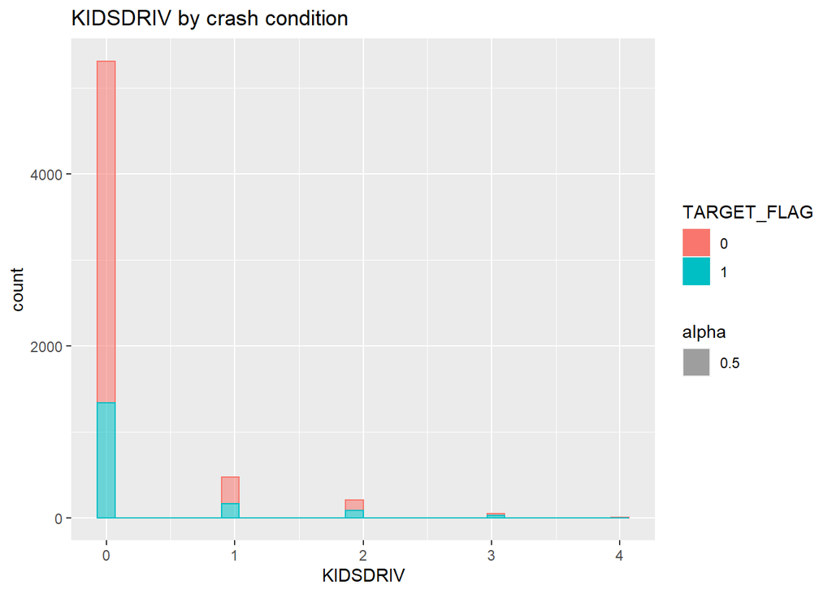

```r
(x<-make_hist(var="KIDSDRIV"))
```

```r
#(y<-make_box(var='KIDSDRIV'))
```

The number of kid drivers dont seem to affect the probability of crashing the car.

lets run a fisher exact test to determine if the distributions are different.

```r
t<-table(df_crash$TARGET_FLAG,df_crash$KIDSDRIV)
fisher.test(table(df_crash$TARGET_FLAG,df_crash$KIDSDRIV))
```

```
##
##  Fisher's Exact Test for Count Data
##
## data:  table(df_crash$TARGET_FLAG, df_crash$KIDSDRIV)
## p-value = 6.841e-10
## alternative hypothesis: two.sided
```

```r
prop.table(t)
```

```
##
##                0            1            2            3            4
##   0 0.6580645161 0.0512820513 0.0210090984 0.0043010753 0.0003308519
##   1 0.2206782465 0.0269644334 0.0133995037 0.0039702233 0.0000000000
```

This means that there is a difference between kids driving and the amount a car is crashed, so we wont immediatley exclude it.

*AGE*

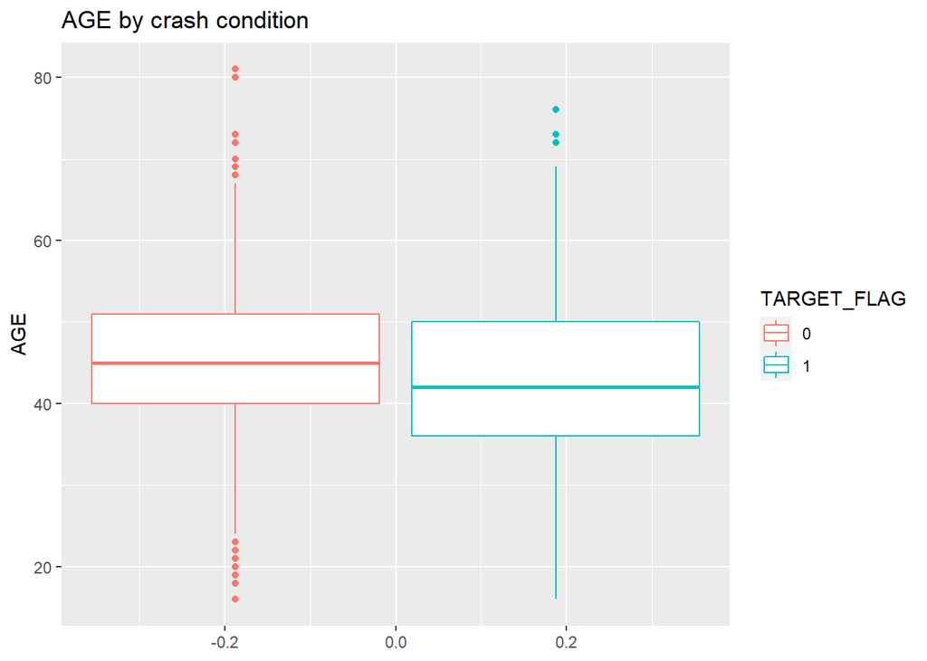

```r
(x<-make_box(var='AGE'))
```

The standard deviations look approximately equal, so we wont make any changes or exclude *AGE* at the moment

*HOMEKIDS*

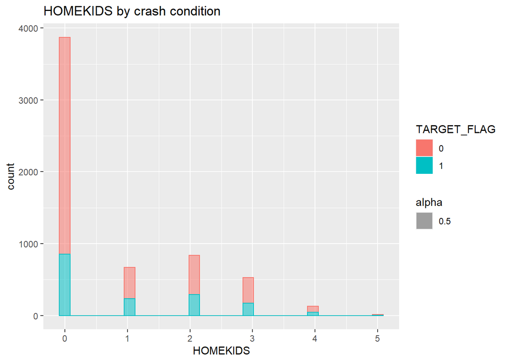

```r
(make_hist(var='HOMEKIDS'))
```

As for *KIDSDRIV* there seems to be a larger probability of not crashing if you have zero kids. Lets look at an interaction plot between the two variables

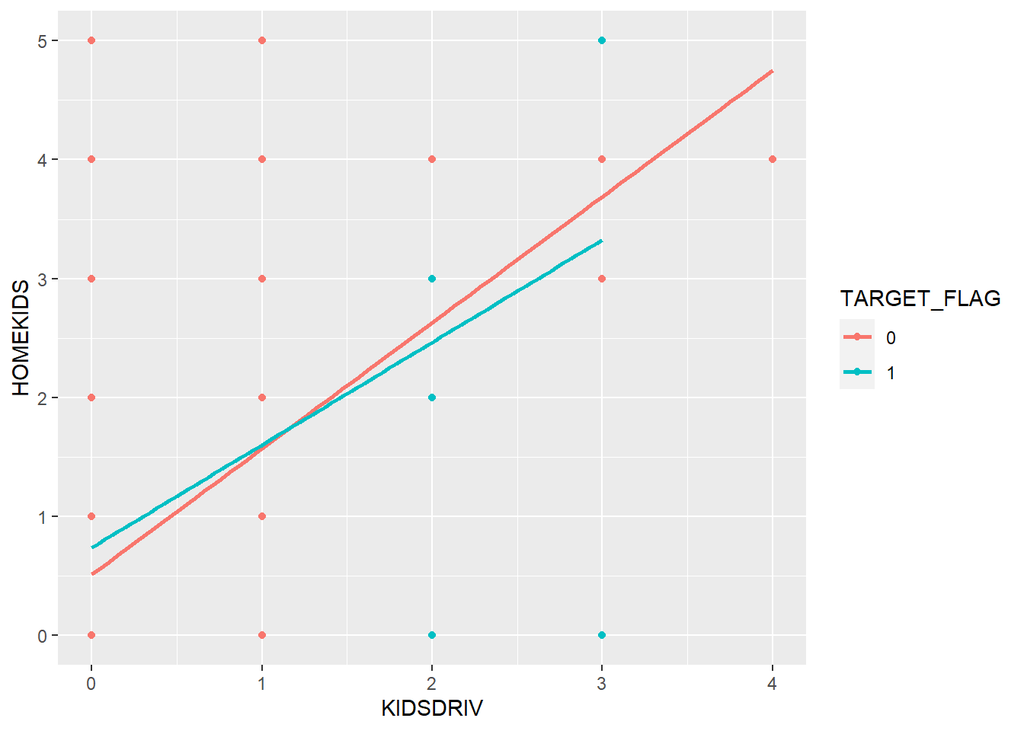

```r
(make_i())
```

Im not sure if we are allowed to do this with integer data, but it does look like there is a correlation, and since the regressions intersect it might make sense to add an interaction term in our regression

*YOJ*

This is *years on job*, the intuition is that the longer people stay on the job are less likely to crash.

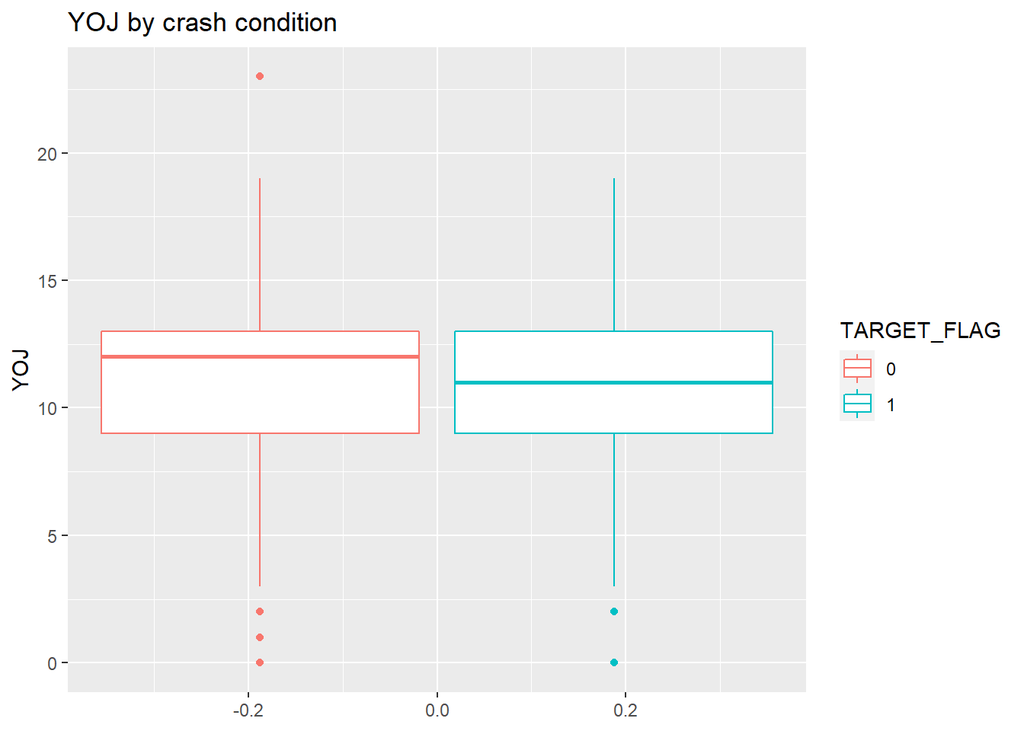

```r
(make_box(var='YOJ'))
```

This interaction doesnt seem to be born out by the boxplots, maybe looking at a histogram would help.

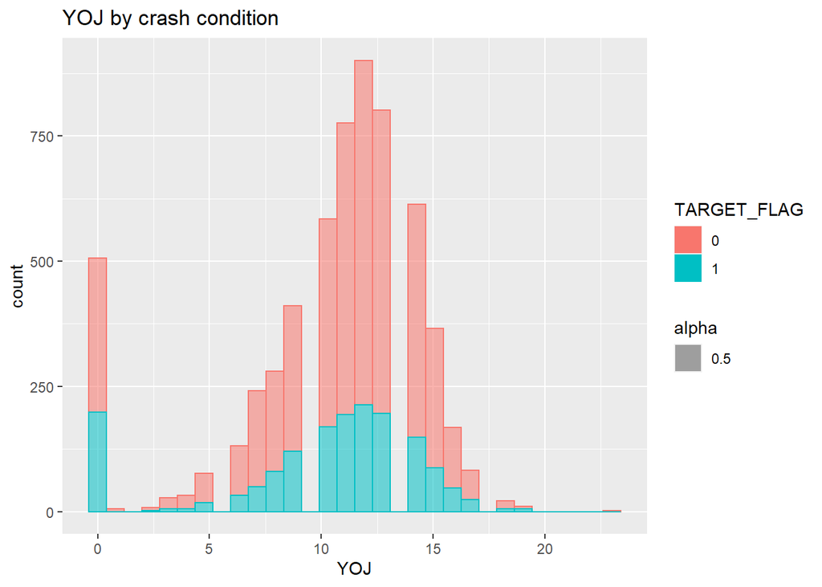

```r
(make_hist(var='YOJ'))
```

use a KS test to see if the data comes from the same distribution

```r
YOJ_crash<-df_crash%>%dplyr::filter(TARGET_FLAG==1)%>%pull(YOJ)
YOJ_no<-df_crash%>%dplyr::filter(TARGET_FLAG==0)%>%pull(YOJ)
ks.test(as.vector(YOJ_crash),as.vector(YOJ_no))
```

```
##
##  Two-sample Kolmogorov-Smirnov test
##
## data:  as.vector(YOJ_crash) and as.vector(YOJ_no)
## D = 0.06025, p-value = 0.0003877
## alternative hypothesis: two-sided
```

it does not, so it cannot be discounted. Now lets looks at the data OUTSIDE of zero years. Maybe that comes from the same distribution

```r
YOJ_crash<-df_crash%>%dplyr::filter(TARGET_FLAG==1 & YOJ>0)%>%pull(YOJ)
YOJ_no<-df_crash%>%dplyr::filter(TARGET_FLAG==0 & YOJ>0)%>%pull(YOJ)
ks.test(as.vector(YOJ_crash),as.vector(YOJ_no))
```

```
##
##  Two-sample Kolmogorov-Smirnov test
##
## data:  as.vector(YOJ_crash) and as.vector(YOJ_no)
## D = 0.025851, p-value = 0.4857
## alternative hypothesis: two-sided
```

Interestingly, the data OUTSIDE of the zero values DO come from the same distribution. We will add a YOJ_ZERO factor for our analysis.

```r
df_crash<-df_crash%>%mutate(YOJ_ZERO=case_when(YOJ>0~FALSE,
                                    TRUE~TRUE))
```

*INCOME*

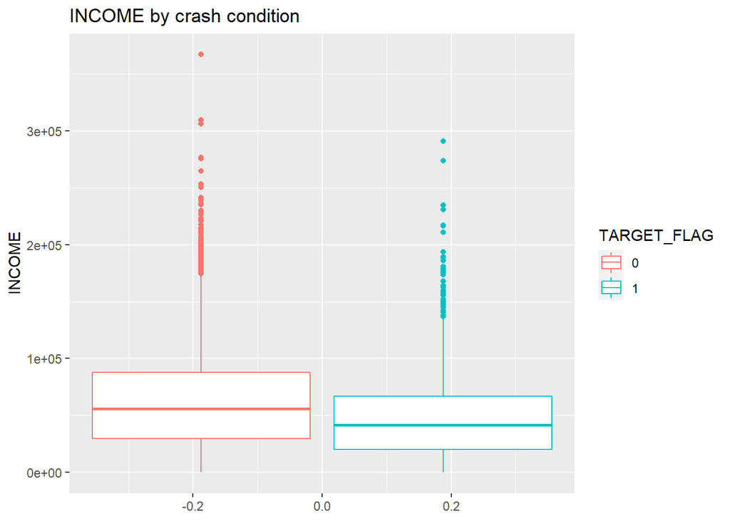

```r
(make_box(var='INCOME'))
```

Again, there seems to be a slight difference between the means and standard deviations, but lets check if this is just a function of more zeros being added.

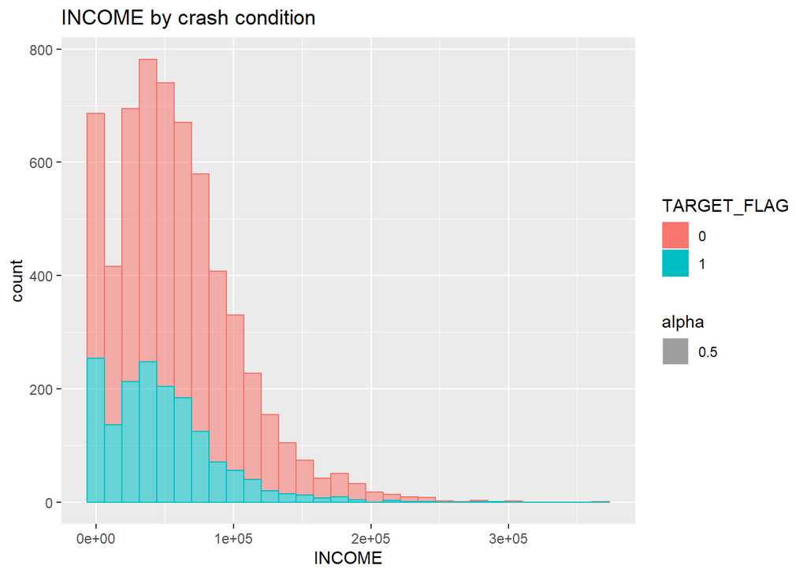

```r
(make_hist(var='INCOME'))
```

It does look like there are slightly more zero income proportionally for car crashers. Lets exclude them and run a KS test again

```r
INCOME_crash<-df_crash%>%dplyr::filter(TARGET_FLAG==1 & INCOME>0)%>%pull(INCOME)
INCOME_no<-df_crash%>%dplyr::filter(TARGET_FLAG==0 & INCOME>0)%>%pull(INCOME)
ks.test(as.vector(INCOME_crash),as.vector(INCOME_no))
```

```
##
##  Two-sample Kolmogorov-Smirnov test
##
## data:  as.vector(INCOME_crash) and as.vector(INCOME_no)
## D = 0.15388, p-value < 2.2e-16
## alternative hypothesis: two-sided
```

*PARENT1*

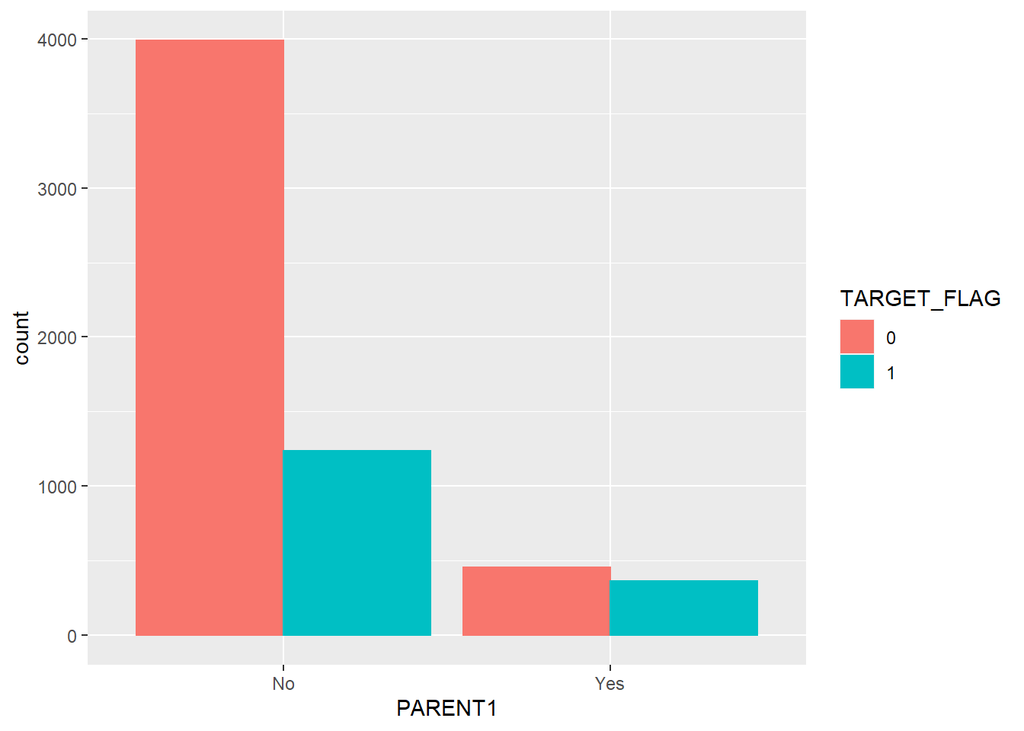

```r
ggplot(df_crash,aes(x=PARENT1,color=TARGET_FLAG,fill=TARGET_FLAG))+geom_bar(position='dodge')
```

1 parent households seem MUCH more likely to have a crash. The correlation seems strong enough visually, that futher testing wont be needed

*HOME_VAL*

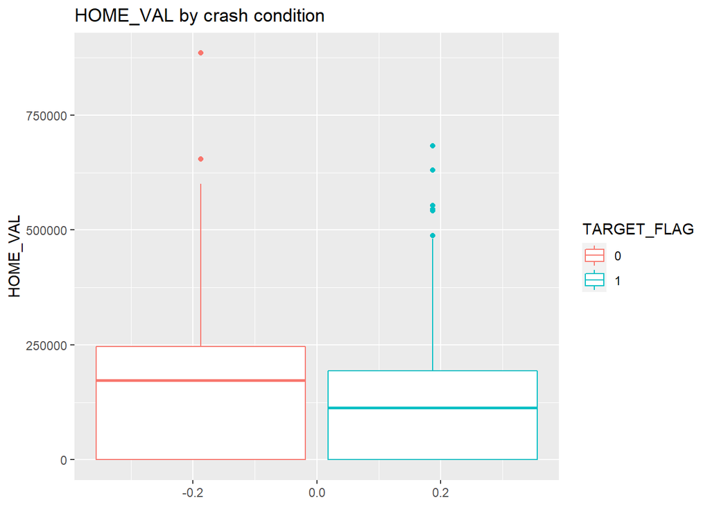

```r
(make_box(var='HOME_VAL'))
```

this might be better observed as a histogram

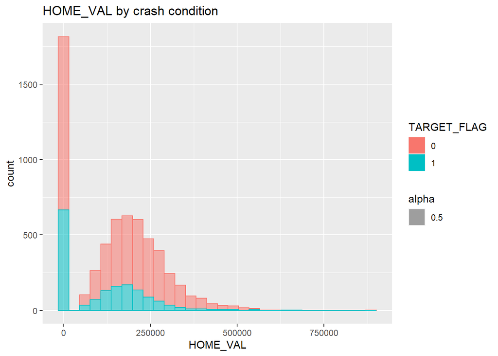

```r
(make_hist(var='HOME_VAL'))
```

Lets look at whether these are from the same distribution

```r
HOME_VAL_crash<-df_crash%>%dplyr::filter(TARGET_FLAG==1 & HOME_VAL>100)%>%pull(HOME_VAL)
HOME_VAL_no<-df_crash%>%dplyr::filter(TARGET_FLAG==0 & HOME_VAL>100)%>%pull(HOME_VAL)
ks.test(as.vector(HOME_VAL_crash),as.vector(HOME_VAL_no))
```

```
##
##  Two-sample Kolmogorov-Smirnov test
##
## data:  as.vector(HOME_VAL_crash) and as.vector(HOME_VAL_no)
## D = 0.16763, p-value < 2.2e-16
## alternative hypothesis: two-sided
```

Even when controlling for zeros, it looks like there is a meaningful difference between these two distributions. No changes are advised at the moment.

*MSTATUS*

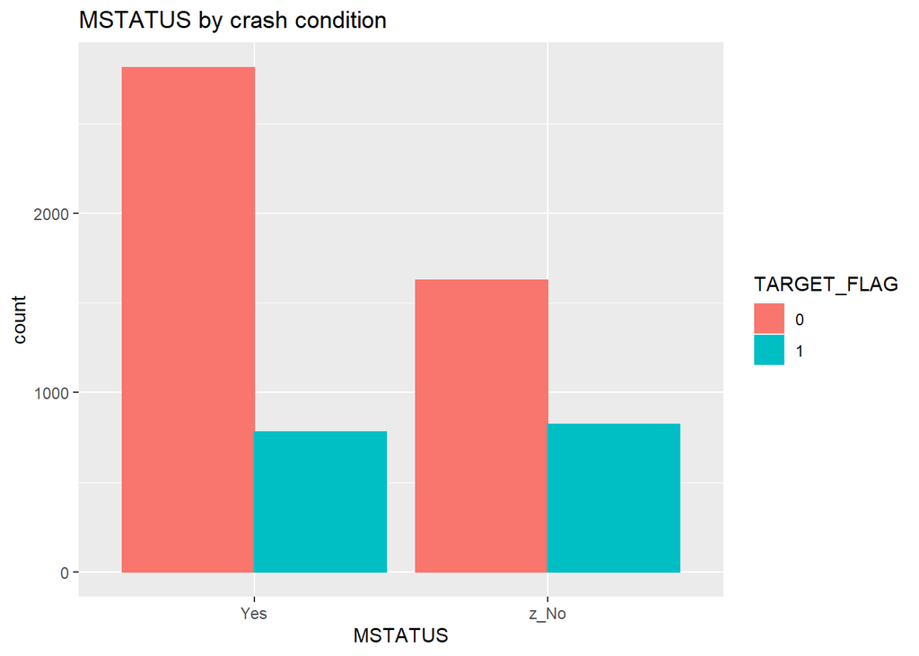

```r
(make_bar())
```

There seems to be a significant difference in MSTATUS and probability of crashing. No further investigation is needed at the moment, and no transformations are reccomended

*SEX*

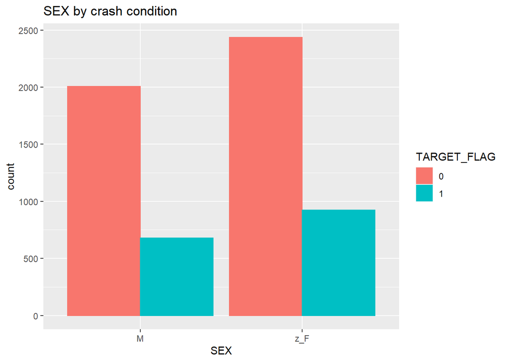

```r
(make_bar(var='SEX'))
```

```r
t<-table(df_crash$TARGET_FLAG,df_crash$SEX)
chisq.test(t)
```

```
##
##  Pearson's Chi-squared test with Yates' continuity correction
##
## data:  t
## X-squared = 3.375, df = 1, p-value = 0.06619
```

The null hypothesis cannot be rejected, so we will reccomend to DROP the sex variable.

*Education*

```r
levels(df_crash$EDUCATION)
```

```
## [1] "<High School"  "Bachelors"     "Masters"       "PhD"
## [5] "z_High School"
```

Education levels are ordinal, so we should order them and convert to numeric levels for simplicity

```r
df_crash$EDUCATION<-as.factor(as.numeric(factor(df_crash$EDUCATION, levels=c('<High School','z_High School','Bachelors','Masters','PhD'),ordered=TRUE)))
```

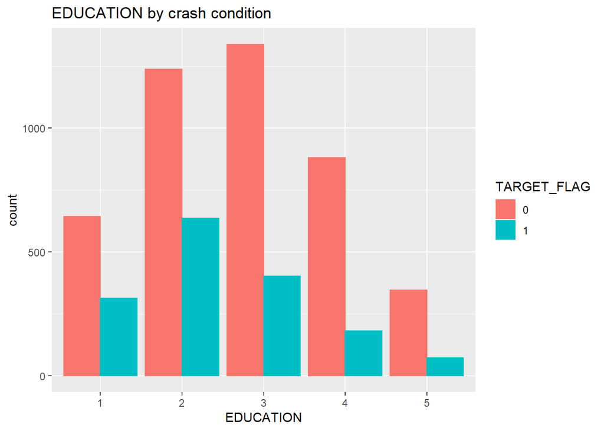

```r
(make_bar(var='EDUCATION'))
```

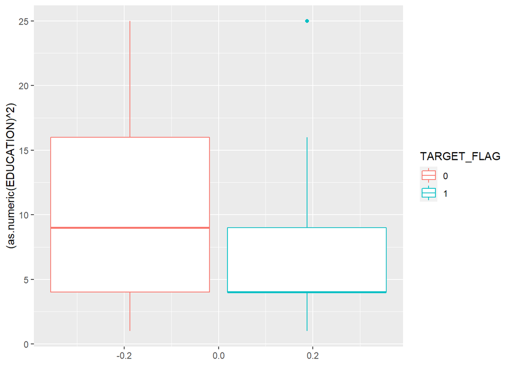

```r
ggplot(df_crash,aes(y=(as.numeric(EDUCATION)^2),group=TARGET_FLAG,color=TARGET_FLAG))+geom_boxplot()
```

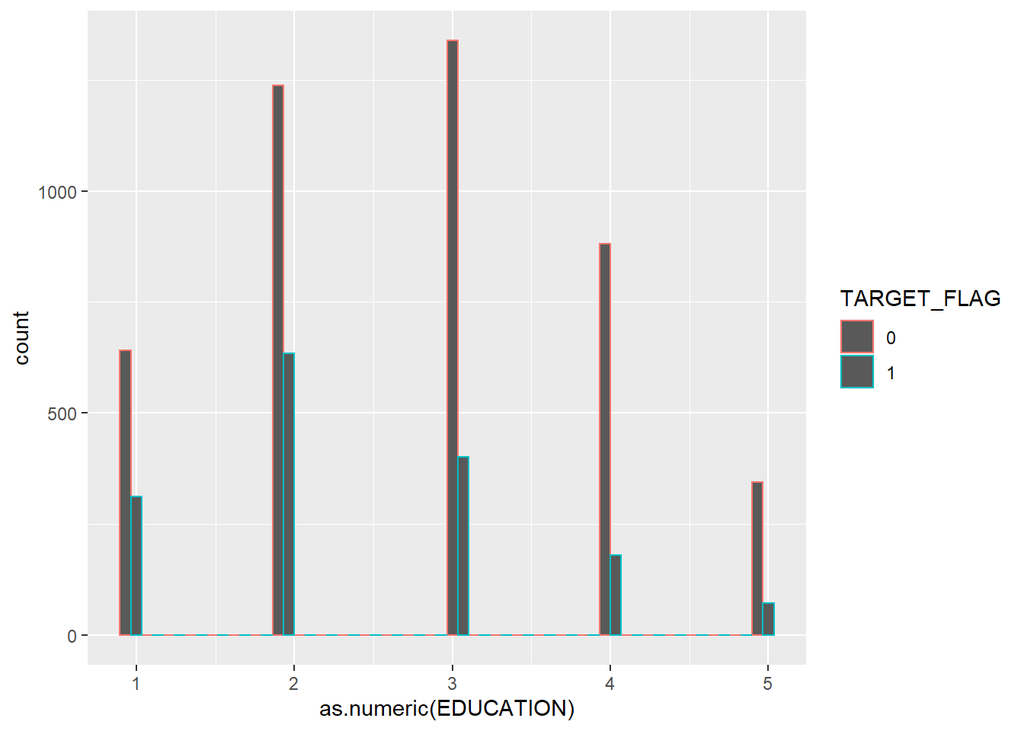

```r
ggplot(df_crash,aes(x=as.numeric(EDUCATION),group=TARGET_FLAG,color=TARGET_FLAG))+geom_histogram(position='dodge')
```

When treating the education levels as a numeric value, it is interesting that the median value is high school for crashers, and bachelors for non-crashers. The data isn’t bimodal enough to justify using a HIGH_SCHOOL factor, but we might want to keep it as a numeric instead of a ordinal categorical.

```r
chisq.test(table(df_crash$TARGET_FLAG,df_crash$EDUCATION))
```

```
##
##  Pearson's Chi-squared test
##
## data:  table(df_crash$TARGET_FLAG, df_crash$EDUCATION)
## X-squared = 150.31, df = 4, p-value < 2.2e-16
```

*JOB*

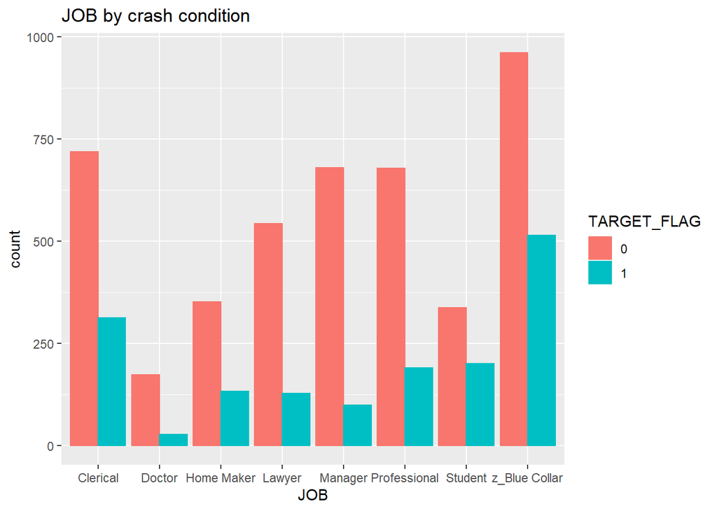

```r
(make_bar(var='JOB'))
```

```r
(t<-table(df_crash$TARGET_FLAG,df_crash$JOB))
```

```
##
##     Clerical Doctor Home Maker Lawyer Manager Professional Student
##   0      719    173        351    543     680          678     337
##   1      312     27        133    127      99          190     200
##
##     z_Blue Collar
##   0           962
##   1           514
```

```r
chisq.test(t)
```

```
##
##  Pearson's Chi-squared test
##
## data:  t
## X-squared = 214.53, df = 7, p-value < 2.2e-16
```

There is a possibility that this vector could be ordinal if you could rank the profession by income? maybe we should check for colinearity with income when it comes up.

*TRAVTIME*

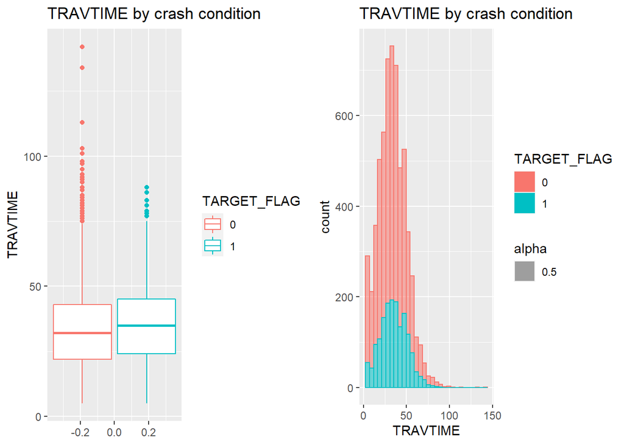

```r
a<-(make_box(var='TRAVTIME'))
b<-(make_hist(var='TRAVTIME'))
library(ggpubr)
ggarrange(a,b)
```

These distributions look very similar, and the means and standard deviations look similar as well

```r
TRAVTIME_crash<-df_crash%>%dplyr::filter(TARGET_FLAG==1 )%>%pull(TRAVTIME)
TRAVTIME_no<-df_crash%>%dplyr::filter(TARGET_FLAG==0 )%>%pull(TRAVTIME)
ks.test(as.vector(TRAVTIME_crash),as.vector(TRAVTIME_no))
```

```
##
##  Two-sample Kolmogorov-Smirnov test
##
## data:  as.vector(TRAVTIME_crash) and as.vector(TRAVTIME_no)
## D = 0.063936, p-value = 0.0001319
## alternative hypothesis: two-sided
```

The metrics for this variable look good and no changes are reccommended

*CAR_USE*

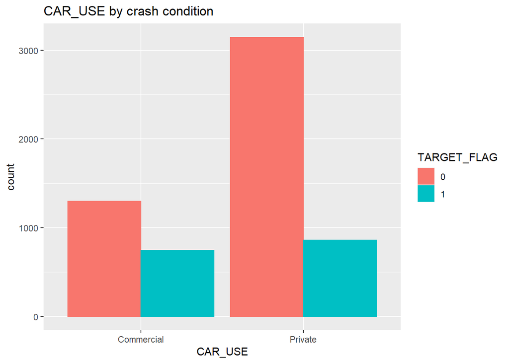

```r
(make_bar(var='CAR_USE'))
```

CAR_USE seems to be important just by visual inspection, no futher analysis at this time

*BLUEBOOK*

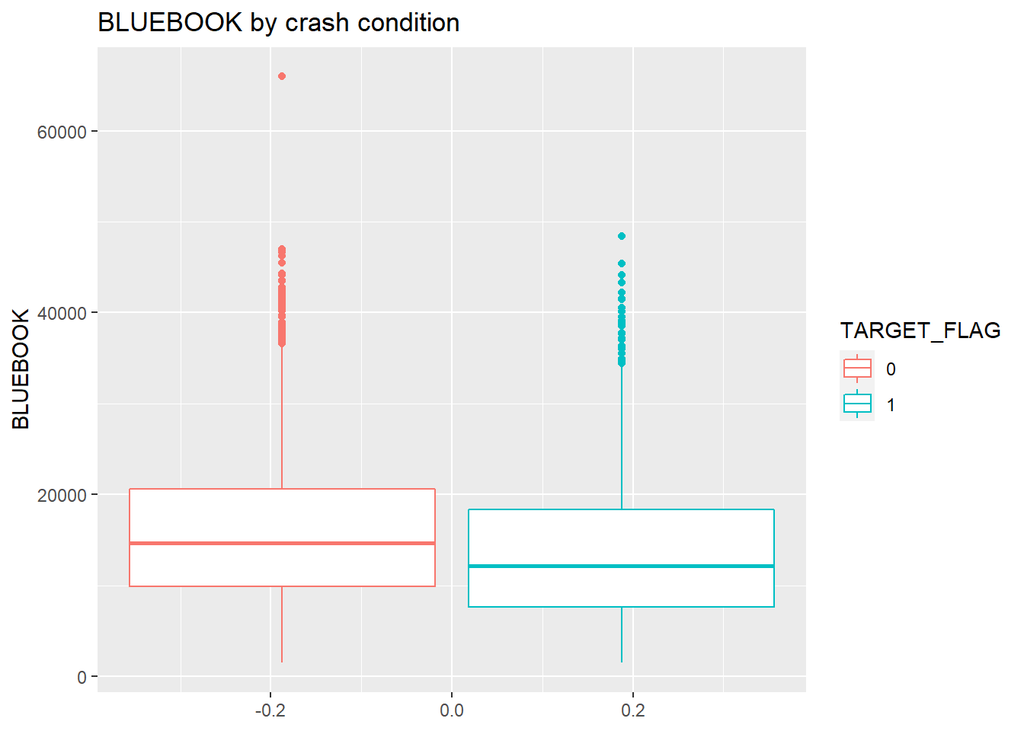

```r
(make_box(var="BLUEBOOK"))
```

Looks ok by visual inspection, no futher analysis at this time

*TIF*

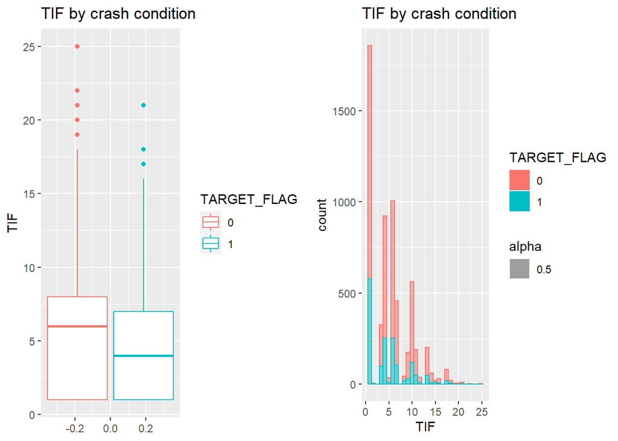

```r
a<-(make_box(var="TIF"))
b<-(make_hist(var="TIF"))
ggarrange(a,b)
```

lets check if the distributions are different omitting the zero level (no result.)

Look at the density function.

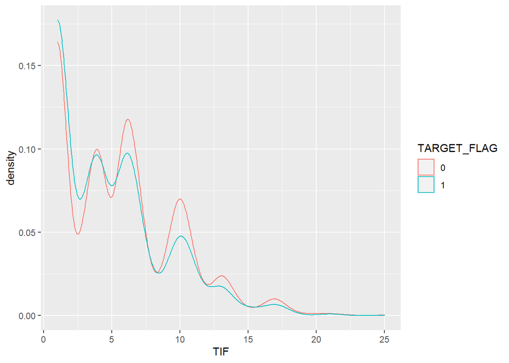

```r
ggplot(df_crash,aes(x=TIF,color=TARGET_FLAG))+geom_density()
```

Both categories of this variable are clearly products of the same function, just with different amplitudes. Maybe if you could Identify the wave function for each, you could take a data point and determine the probability that it belonged to one function or the other…. Interesting exercise, but I’m not sure how useful it would be. Consider omitting this.

*CAR_TYPE*

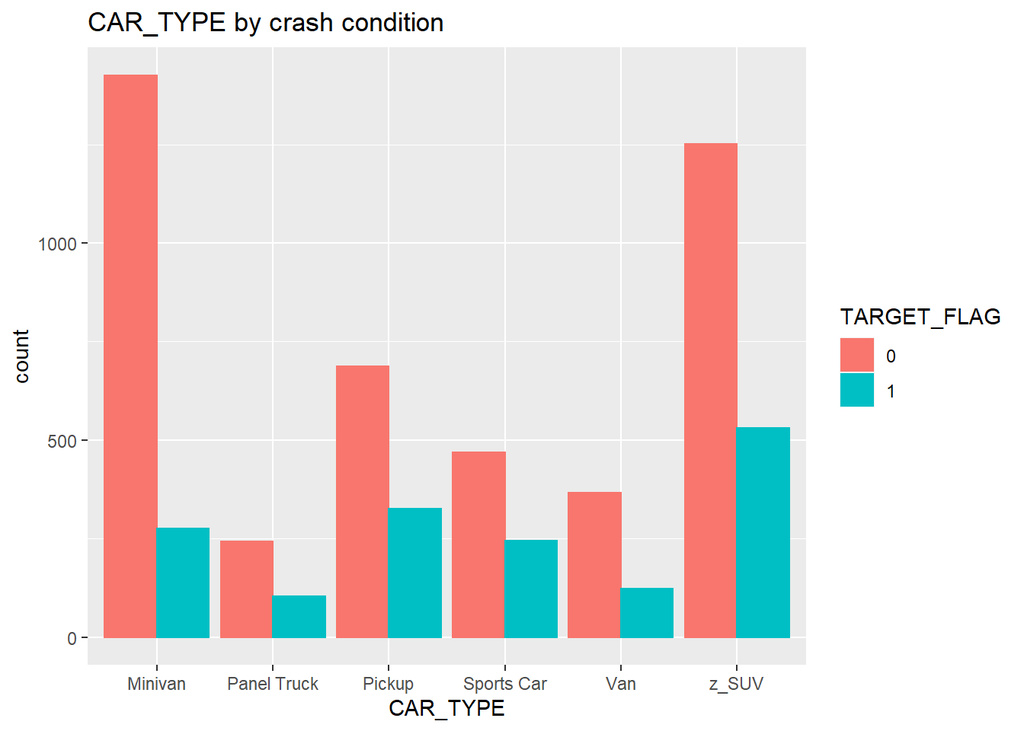

```r
(make_bar(var='CAR_TYPE'))
```

```r
(t<-table(df_crash$TARGET_FLAG,df_crash$CAR_TYPE))
```

```
##
##     Minivan Panel Truck Pickup Sports Car  Van z_SUV
##   0    1426         243    688        469  366  1251
##   1     275         104    326        245  122   530
```

```r
chisq.test(t)
```

```
##
##  Pearson's Chi-squared test
##
## data:  t
## X-squared = 144.66, df = 5, p-value < 2.2e-16
```

Looks ok, no transformations reccomended.

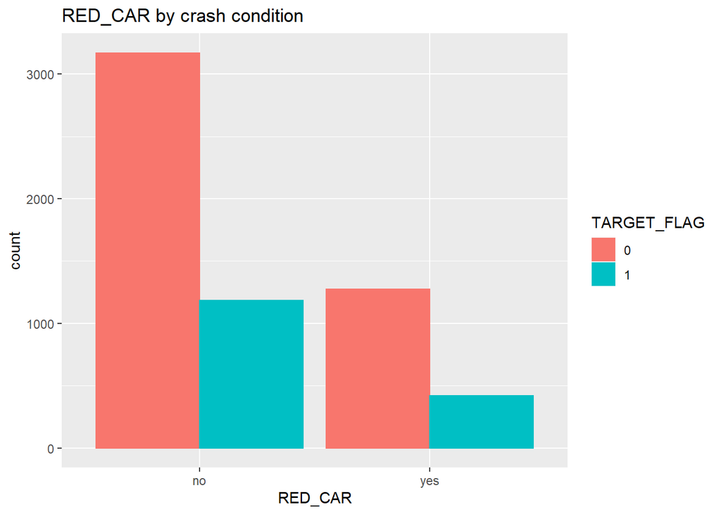

```r
(make_bar(var='RED_CAR'))
```

```r
t<-table(df_crash$TARGET_FLAG,df_crash$RED_CAR)
chisq.test(t)
```

```
##
##  Pearson's Chi-squared test with Yates' continuity correction
##
## data:  t
## X-squared = 3.7022, df = 1, p-value = 0.05434
```

These variables are independent, reccomend not including.

*OLDCLAIM*

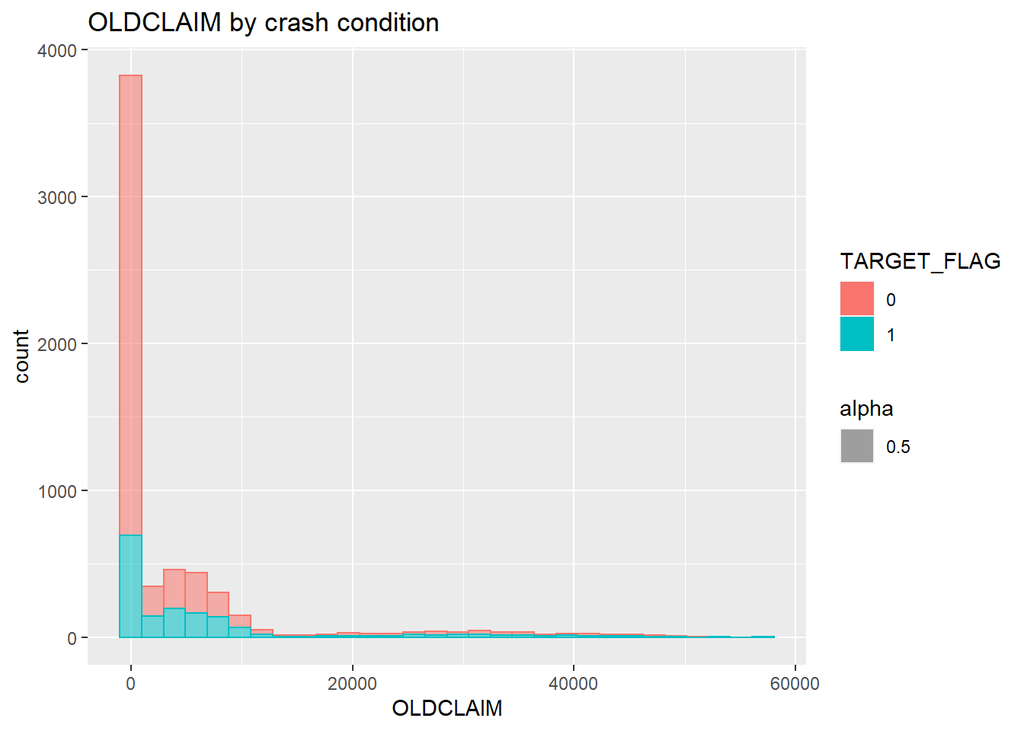

```r
(make_hist(var='OLDCLAIM'))
```

looks like another distribution loaded up with zeros, lets check if they are differnt if we deselect them .

```r
OLDCLAIM_crash<-df_crash%>%dplyr::filter(TARGET_FLAG==1 & OLDCLAIM>0)%>%pull(OLDCLAIM)
OLDCLAIM_no<-df_crash%>%dplyr::filter(TARGET_FLAG==0 & OLDCLAIM>0 )%>%pull(OLDCLAIM)
ks.test(as.vector(OLDCLAIM_crash),as.vector(OLDCLAIM_no))
```

```
##
##  Two-sample Kolmogorov-Smirnov test
##
## data:  as.vector(OLDCLAIM_crash) and as.vector(OLDCLAIM_no)
## D = 0.025202, p-value = 0.8743
## alternative hypothesis: two-sided
```

This is the case, all of the difference is loaded in the zeros, lets make a factor variable

```r
df_crash<-df_crash%>%mutate(OLDCLAIM_ZERO=case_when(OLDCLAIM==0~TRUE,
                                  TRUE~FALSE))
```

*CLM_FREQ*

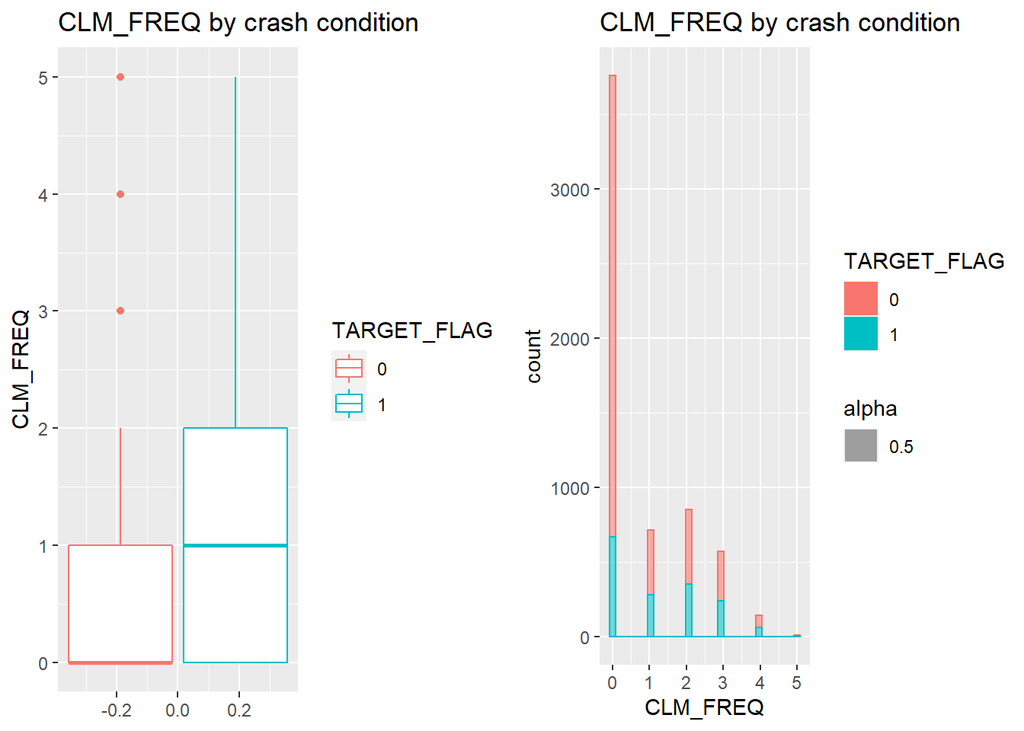

```r
a<-(make_box(var='CLM_FREQ'))
b<-(make_hist(var='CLM_FREQ'))
ggarrange(a,b)
```

check if this is overloaded with zeros.

```r
CLM_FREQ_crash<-df_crash%>%dplyr::filter(TARGET_FLAG==1 & CLM_FREQ>0)%>%pull(CLM_FREQ)
CLM_FREQ_no<-df_crash%>%dplyr::filter(TARGET_FLAG==0 & CLM_FREQ>0 )%>%pull(CLM_FREQ)
ks.test(as.vector(CLM_FREQ_crash),as.vector(CLM_FREQ_no))
```

```
##
##  Two-sample Kolmogorov-Smirnov test
##
## data:  as.vector(CLM_FREQ_crash) and as.vector(CLM_FREQ_no)
## D = 0.019079, p-value = 0.9879
## alternative hypothesis: two-sided
```

It is indeed, lets make a factor

```r
df_crash<-df_crash%>%mutate(CLM_FREQ_ZERO=case_when(CLM_FREQ==0~TRUE,
                                  TRUE~FALSE))
```

```r
table(df_crash$OLDCLAIM_ZERO,df_crash$CLM_FREQ_ZERO)
```

```
##
##         FALSE TRUE
##   FALSE  2286    0
##   TRUE      0 3759
```

drop one of these.

*REVOKED*

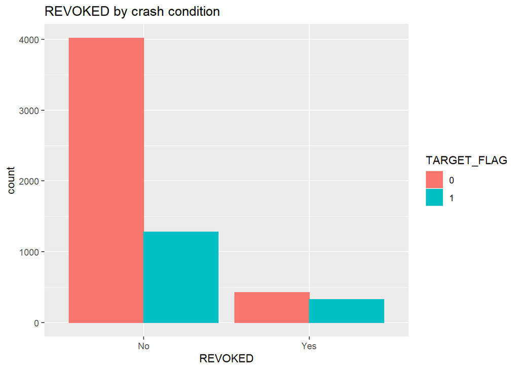

```r
(make_bar(var="REVOKED"))
```

looks good by inspection, no changes suggested.

*MVR_PTS*

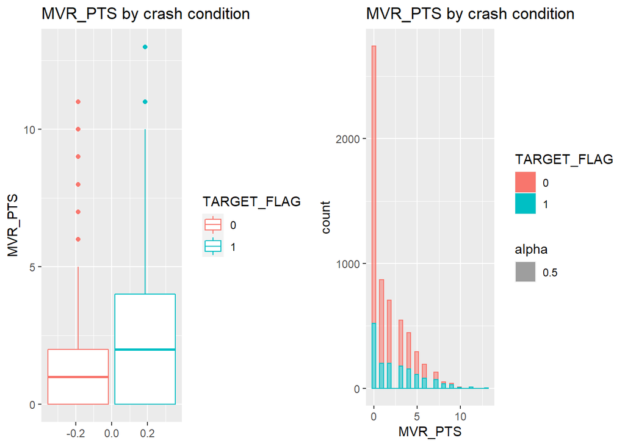

```r
a<-(make_box(var="MVR_PTS"))
b<-(make_hist(var='MVR_PTS'))
ggarrange(a,b)
```

These look like different distributions, might want to interact them because their standard deviations look so different.

*CAR_AGE*

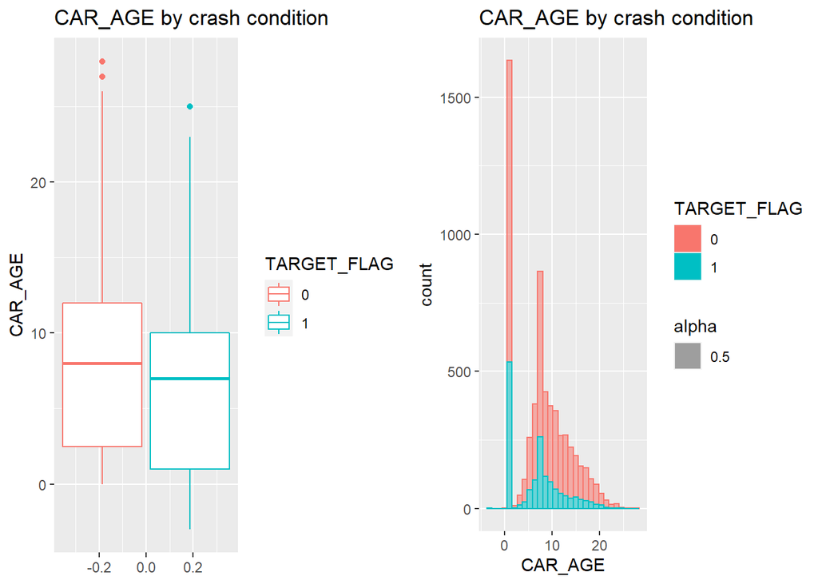

```r
a<-make_box(var="CAR_AGE")
b<-make_hist(var='CAR_AGE')
ggarrange(a,b)
```

```r
CAR_AGE_crash<-df_crash%>%dplyr::filter(TARGET_FLAG==1 & CAR_AGE>3 )%>%pull(CAR_AGE)
CAR_AGE_no<-df_crash%>%dplyr::filter(TARGET_FLAG==0 & CAR_AGE>3)%>%pull(CAR_AGE)
ks.test(as.vector(CAR_AGE_crash),as.vector(CAR_AGE_no))
```

```
##
##  Two-sample Kolmogorov-Smirnov test
##
## data:  as.vector(CAR_AGE_crash) and as.vector(CAR_AGE_no)
## D = 0.1168, p-value = 7.212e-10
## alternative hypothesis: two-sided
```

These are different distributions, even accounting vor the low value difference. no transformations reccomended

*URBANICITY*

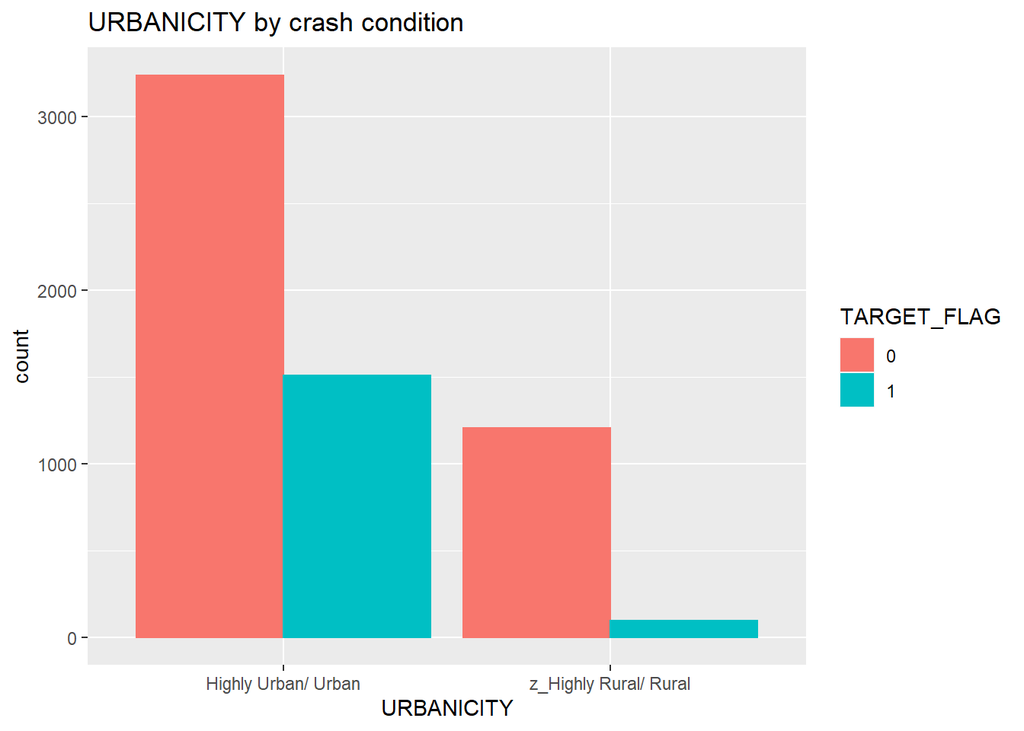

```r
(make_bar(var='URBANICITY'))
```

These look different by inspection, no transformations reccomended.